# FigureYa226scRNA_cNMF

**Author(s)**: Jianing Gao  
**Reviewer(s)**: Ying Ge, Junyi Shen  
**Date**: 2025-09-23

# Academic Citation

If you use this code in your work or research, we kindly request that you cite our publication:

Xiaofan Lu, et al. (2025). FigureYa: A Standardized Visualization Framework for Enhancing Biomedical Data Interpretation and Research Efficiency. iMetaMed. https://doi.org/10.1002/imm3.70005

# 需求描述

# Requirement

您好，参加了FigureYa194pySCENIC，收获满满，老师在讲课中提到的cNMF方法分析单细胞数据能不能再组织一次课？ Hello, I participated in FigureYa194pySCENIC and gained a lot. Can you organize another class on the cNMF method for analyzing single-cell data mentioned by the teacher in the lecture?

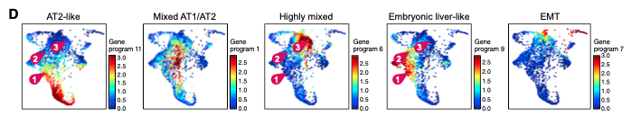

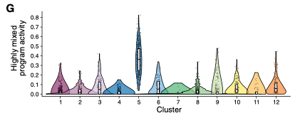

出自https://linkinghub.elsevier.com/retrieve/pii/S1535610820303160 Fromhttps://linkinghub.elsevier.com/retrieve/pii/S1535610820303160

**例文的分析流程**

例文是一个很好的肿瘤单细胞的案例，通讯作者之一是单细胞领域的明星Aviv Regev，她的文章的分析方法非常丰富，有很多值得借鉴的地方：

- 前面的细胞类型鉴定很经典（可参考FigureYa177RNAvelocity）
- CNV推断（Figure 1G的画法可参考FigureYa166scCNV）
- Single Cell Gene Set Enrichment（可参考FigureYa160scGSVA）
- **cNMF提取expression program**，为本文重点内容（FigureYa223scNMF用R版本的NMF做类似的分析，来自不同作者，可对比学习）
- 优化传输模型分析发育轨迹（可参考FigureYa40lineage）

**Analysis Process for the Example Paper**

The example paper is a great example of single-cell tumor analysis. One of the corresponding authors is Aviv Regev, a leading figure in the single-cell field. Her article offers a wealth of analytical methods, offering valuable insights:

- The previous section on cell type identification is a classic example (see Figure Ya177: RNA velocity)
- CNV inference (see Figure Ya166: scCNV for the plot of Figure 1G)
- Single Cell Gene Set Enrichment (see Figure Ya160: scGSVA)
- **cNMF expression extraction program**, the focus of this article (Figure Ya223: scNMF uses the R version of NMF for similar analysis, from different authors, for comparison and learning).
- Optimizing the transmission model to analyze developmental trajectories (see Figure Ya40: lineage)

# 应用场景

# Application Scenarios

利用cNMF提取expression programs，并通过整合其它已发表的数据，利用Gene set analysis来推断expression programs的生物学意义。 Use cNMF to extract expression programs and, by integrating other published data, use gene set analysis to infer the biological significance of these expression programs.

想要深入了解cNMF，请看本文档后半部分的“附：cNMF算法概述”。 For a more in-depth understanding of cNMF, please see the “Appendix: Overview of the cNMF Algorithm” later in this document.

> 直播回放 Live Replay

链接：https://pan.baidu.com/s/1qAyEMn7oCjBgbccg_4pHyA，提取码：1mwb Link: https://pan.baidu.com/s/1qAyEMn7oCjBgbccg_4pHyA, Extraction Code: 1mwb

# 环境设置

# Environment Setup

安装python版本的cNMF，参考[cNMF@github](https://github.com/dylkot/cNMF/) To install the Python version of cNMF, refer to [cNMF@github](https://github.com/dylkot/cNMF/)

```bash
## step_1 create env
conda create -n cnmf_env --yes --channel bioconda --channel conda-forge --channel defaults fastcluster==1.1.25 matplotlib==3.1.1 numpy==1.17.3 palettable==3.3.0 pandas==0.25.2 scipy==1.3.1 scikit-learn==0.21.3 cython==0.29.13 pyyaml==5.1.2 scanpy==1.4.4.post1 parallel && conda clean --yes --all
## step_2 activate env
conda activate cnmf_env
## step_3 clone cNMF source code
cd /path/to/scRNA_cNMF
git clone https://github.com/dylkot/cNMF.git
## test env
python cNMF/cnmf.py -h
## step_4 install jupyter for interactive analysis
conda install --yes jupyterlab==1.1.4 ipython==7.8.0 && conda clean --yes --all
```

# 输入文件

# Input file

例文的实验设计：作者用不同的小鼠模型模拟肺腺癌（lung adenocarcinoma, LUAD）的发生过程。样本是time series的设计，不同的模型鼠模拟了不同stage的肺癌。通过取不同时间点的AT2细胞（tdTomato+），利用Smart-Seq2进行单细胞建库。 Experimental Design: The authors used different mouse models to simulate the progression of lung adenocarcinoma (LUAD). The sample design was a time series, with different mouse models simulating different stages of lung cancer. AT2 cells (tdTomato+) were collected at different time points and single-cell libraries were constructed using Smart-Seq2.

数据下载链接：GSE154989。下载后解压缩，放入data文件夹（同微云里的data.zip，建议从GEO下载） Data download link: GSE154989. After downloading, unzip the file and place it in the data folder (the same as data.zip in Weiyun, but downloading from GEO is recommended).

富集分析时用到多个gene set，文件较大，已上传至微云https://share.weiyun.com/zyb8iF5J。下载ref.zip，解压缩后放入当前文件夹。 Multiple gene sets were used in the enrichment analysis, and the files are large. They have been uploaded to Weiyun https://share.weiyun.com/zyb8iF5J. Download ref.zip, unzip it, and place it in the current folder.

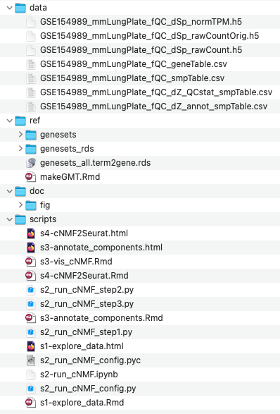

# 代码目录

# Code Directory

位于scripts文件夹 Located in the `scripts` folder

## 特征基因选择

## Feature Gene Selection

作者对75%的细胞随机抽样200次来鉴定特征基因，这一点值得借鉴（后文详述）。准备cNMF的输入文件。 The authors randomly sampled 75% of cells 200 times to identify feature genes, which is worth learning from (discussed in detail later). Prepare the cNMF input file.

见`s1-explore_data.Rmd` See `s1-explore_data.Rmd`

## cNMF

**降维**：作者选择NMF进行降维。在此基础上进一步进行tSNE和PHATE maps进行可视化。 **Dimensionality Reduction**: The authors used NMF for dimensionality reduction. Based on this, tSNE and PHATE maps were further used for visualization.

**聚类**：在NMF上计算cosine距离，kNN稳定优化图聚类。 **Clustering**: Cosine distance was calculated on NMF, and kNN was used for graph clustering.

见`s2-run_cNMF.ipynb` See `s2-run_cNMF.ipynb` and `s3-vis_cNMF.Rmd`

## cNMF结果可视化 - Expression program

作者借鉴了cNMF的方法提取Expression programs。这是本教程的重点，我们没有完全使用作者的分析方法，而是使用cNMF这个计算工具，得到了和本文类似的结果。

见`s2-run_cNMF.ipynb`及`s3-vis_cNMF.Rmd`

## 基因富集分析 - Gene set analysis

## Gene Enrichment Analysis - Gene Set Analysis

这是本文又一个值得借鉴的地方，本文整合了多个gene set注释信息（见TableS9，以及ref文件夹下的`makeGMT.Rmd`代码）对experssion program进行富集分析 This is another area where this paper is worth learning from. We integrated annotation information from multiple gene sets (see Table S9 and `makeGMT.Rmd` in the `ref` folder) to perform enrichment analysis on the experssion program.

见`s3-vis_cNMF.Rmd` See `s3-vis_cNMF.Rmd`

## 将cNMF的结果导入Seurat对象，并用Seurat内置的可视化函数进行可视化。

## Importing cNMF results into a Seurat object and visualizing them using Seurat’s built-in visualization functions.

见`s4-cNMF2Seurat.Rmd` See `s4-cNMF2Seurat.Rmd`

# 附：cNMF算法概述

# Appendix: Overview of the cNMF Algorithm

## Why NMF

NMF是一种soft clustering方法（即给出样本属于某一类的概率），在无需先验知识的条件下，能够很好地提取矩阵中的特征。通过对特征的进一步分析，我们可以给出样本属于某一类的概率。NMF对于连续发育过程的单细胞分析非常有效，结合传统的聚类分析，可以定义出更加复杂的细胞状态和对应的特征基因集合。另外根据我的经验，NMF对batch effect不敏感（batch effect通常会被识别为某一/几个components，不会和具有生物学意义的components混合），非常适用于smart-seq这种低通量，多批次的单细胞建库方法的数据分析。 NMF is a soft clustering method (i.e., giving the probability of a sample belonging to a certain class). It effectively extracts features from matrices without requiring prior knowledge. Further analysis of these features can yield a probability of a sample belonging to a certain class. NMF is highly effective for single-cell analysis of continuous developmental processes. Combined with traditional cluster analysis, it can define more complex cell states and corresponding sets of signature genes. Furthermore, in my experience, NMF is insensitive to batch effects (which are typically identified as one or a few components and not intermingled with biologically meaningful components), making it well-suited for data analysis using low-throughput, multi-batch single-cell library generation methods such as smart-seq.

## NMF(Non-negative Matrix Factorization)

NMF本质上是一种矩阵分解的方法，限制条件是分解后的矩阵中的元素不能为负。以下图为例，我们的单细胞基因表达矩阵是一个行为基因，列为细胞的矩阵。分解后，我们得到两个矩阵，在[cNMF的文章@elife2019](https://elifesciences.org/articles/43803)中，前者称为`GEP(Gene Expression Program) spectra`，记录了基因对每个component的贡献，后者称为`Usage matrix`，简单理解为每个GEP在每个细胞中的Activity。 NMF is essentially a matrix factorization method, with the constraint that the elements of the decomposed matrix cannot be negative. For example, the following figure shows a single-cell gene expression matrix consisting of behavioral genes and cells. After decomposition, we obtain two matrices. In the [cNMF article @elife2019](https://elifesciences.org/articles/43803), the former is called the GEP (Gene Expression Program) spectra, which records the contribution of genes to each component, and the latter is called the usage matrix, which simply represents the activity of each GEP in each cell.

这个矩阵分解形式上可以写为， This matrix decomposition can be formally written as:

$$C_{m,n} = G_{m,k}\times
U_{k,n}$$

C为m个genes，n个cells的基因表达矩阵 C is the gene expression matrix for m genes and n cells.

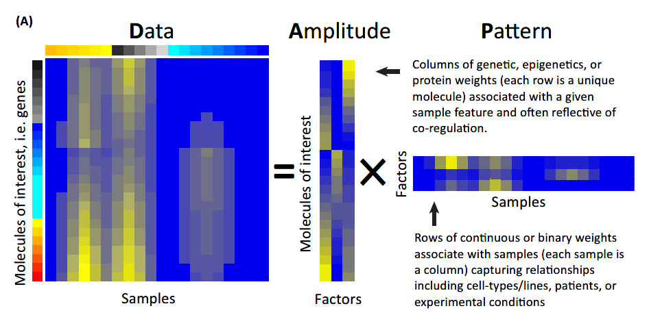

Trends in Genetics, 2018(Figure 2A)

## NMF结果的生物学意义

## Biological Significance of NMF Results

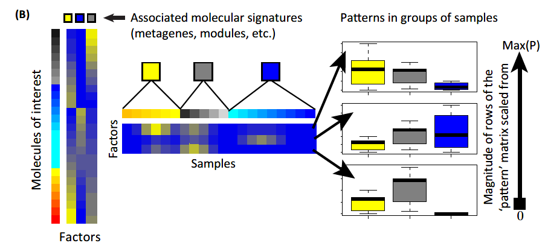

Trends in Genetics, 2018(Figure2B)

我们可以从Usage matrix和GEP spectra matrix两方面出发，赋予NMF结果以生物学解释。 We can provide biological interpretations for NMF results from two perspectives: the usage matrix and the GEP spectra matrix.

- Usage matrix：如上图，Usage Matrix可以将GEP的activity和cell meta信息建立关联性，从而赋予GEP以生物学意义。(表型)
- Usage matrix: As shown in the figure above, the usage matrix can correlate GEP activity with cell meta-information, thereby assigning biological significance to the GEP. (Phenotype)
- GEP spectra matrix：我们可以通过每个GEP中的基因按照权重排序，进而通过GSEA等基因功能分析算法来赋予GEP以生物学意义。(机制)
- GEP spectra matrix: We can rank the genes in each GEP by weight and then assign biological significance to the GEP using gene function analysis algorithms such as GSEA. (Mechanism)

这两个角度合起来，就可以让我们做到从机制到表型的关联。 Combining these two perspectives allows us to link mechanism to phenotype.

## cNMF(consensus NMF)算法

## cNMF (Consensus NMF) Algorithm

cNMF的提出是为了解决求解NMF分解时结果不唯一的问题。 cNMF was proposed to address the issue of non-unique results when solving NMF decomposition.

### a) Data preprocessing

- 过滤UMI<1000的细胞 (self-define)
- 低表达的基因 (1 out of 500 cells)
- Filter cells with UMI < 1000 (self-defined)
- Lowly expressed genes (1 out of 500 cells)

过滤后的矩阵记为（行为细胞，列为基因的矩阵） The filtered matrix is denoted as (behavior cells, gene matrix)

$$C_{ij} (i=1...N cells, j=1...M
genes)$$

- 选择Top H个高度可变的基因（可以使用内置算法*V score*来计算，也可以自己提供基因列表)
- 对这个子矩阵按基因（列）进行方差标准化 (variance scale)
- Select the top H highly variable genes (you can use the built-in algorithm *V score* to calculate, or you can provide your own gene list)
- Normalize the variance of this submatrix by gene (column) (variance scale)

标准化后的子矩阵记为 The normalized submatrix is denoted as

$$\widetilde{C}=\left[ \begin{matrix}...
\frac{C_j}{\sigma(C_j)} ...\end{matrix} \right] , j \in \{H \
overdispersed \ genes \}$$

【备注】 [Notes]

Ｑ：**数据的预处理部分为何用`variance scale`而非我们常用的`log transformation`?** Q: Why did you use a variance scale instead of the more commonly used log transformation for data preprocessing?

A：作者主要有以下三点考虑 A: The author had the following three main considerations:

1. `log transformation`会引入pseudo count，影响下游分析。
2. Log transformation introduces pseudo counts, which can affect downstream analysis.

> However, we prefer variance scaling because log transformation requires addition of an arbitrary pseudo-count which can substantially impact downstream analysis (William Townes et al., 2019).
2. 在对数空间中，0.1到1的变化和100到1000的变化都是1，但是显然前者更像噪音，后者更可能有生物学意义。
3. In logarithmic space, a change from 0.1 to 1 and a change from 100 to 1000 are both 1, but the former clearly looks more like noise, while the latter is more likely to be biologically meaningful.

> In addition log-transformation renders fold-changes of 0.1 to 1, and 100 to 1000 equivalent in absolute terms. This is undesirable given the current resolution of scRNA-Seq data because the former change can frequently be attributable to noise while we have much greater confidence in the biological significance of the latter.
3. 最后，GEP在对数空间的加法对应到raw matrix上是乘法。作者认为GEP之间的相加比相乘更具有生物学意义。
4. Finally, addition of GEPs in logarithmic space corresponds to multiplication in the raw matrix. The authors suggest that addition of GEPs is more biologically meaningful than multiplication.

> Finally, addition of components in log expression space corresponds to multiplication in raw expression space. We believe additivity to be a more appropriate model than multiplicativity for most GEPs, and therefore do not log-transform the data prior to running cNMF.

Q：**input matrix应该用raw count matrix（UMI counts）还是TPM matrix（normalized by sequence depth）？**

A：cNMF算法没有对测序深度进行归一化，主要是因为 A: The cNMF algorithm does not normalize for sequencing depth, primarily for the following reasons:

1. 测序深度（Technical variation）会体现在Usage Matrix中，后续我们直接对Usage Matrix进行归一化即可
2. Sequencing depth (technical variation) is reflected in the usage matrix, which we can then directly normalize.
3. nUMI高的细胞包含的信息更为丰富，相对于nUMI低的细胞（同种类型的细胞）更能影响cNMF的结果。
4. Cells with high nUMIs contain richer information and thus have a greater impact on cNMF results than cells with low nUMIs (of the same cell type).

   值得注意的是，对于全长单细胞测序技术，例如smart-seq，作者的处理方法是直接将TPM矩阵作为input matrix It is worth noting that for full-length single-cell sequencing technologies, such as smart-seq, the author’s approach is to directly use the TPM matrix as the input matrix

> However, for the Tasic et al. (2016) dataset, which is based on full-transcript sequencing rather than digital UMI counting, we variance-normalized high-variance genes from the TPM matrix directly rather than from the raw count matrix as in the other datasets.

总结来说，就是cNMF算法本身没有对矩阵按照测序深度进行归一化，对于10X数据（或者任何UMI-based technology），直接使用raw counts matrix作为输入即可。对于smart-seq数据（或者任何full-length technology），使用TPM matrix作为输入。 In summary, the cNMF algorithm itself does not normalize the matrix according to sequencing depth. For 10X data (or any UMI-based technology), it is sufficient to use the raw counts matrix as input. For smart-seq data (or any full-length technology), it is sufficient to use the TPM matrix as input.

### b) Consensus non-negative matrix factorization (cNMF)

step1：求解GEP spectra matrix Step 1: Solve the GEP spectra matrix

- 对矩阵$\widetilde{C}$进行R次NMF
- Perform R NMF on the matrix $\widetilde{C}$

  $$\widetilde{C}=U^{(r)}\times G^{(r)}, for
  \ r = 1...R$$

  其中$U^{(r)}$为Usage matrices（N cells $\times$ K programs），$G^{(r)}$为program matrices（K programs $\times$ H genes） Where $U^{(r)}$ is the usage matrix (N cells $\times$ K programs), $G^{(r)}$ is the program matrix (K programs $\times$ H genes).
- 对$G^{(r)}$进行L2范数归一化，这一步归一化是为了方便衡量programs之间的相似性。（**经过L2范数归一化后，一组向量的欧式距离和它们的余弦相似度可以等价**）
- Perform L2 normalization on $G^{(r)}$. This normalization step facilitates measuring the similarity between programs. (**After L2 norm normalization, the Euclidean distance of a set of vectors and their cosine similarity are equivalent**)

  $\widetilde{G}^{(r)} = rowL2Nrom(G^{(r)})$
- 按行拼接 $\widetilde{G}^{(r)}$，得到矩阵$G$（RK programs $\times$ H genes）
- Concatenate $\widetilde{G}^{(r)}$ by row to obtain the matrix $G$ (RK programs $\times$ H genes)

  $G = rbind(\widetilde{G}^{(1)}, ..., \widetilde{G}^{(R)})$

接下来需要对矩阵G进行过滤，舍弃异常的programs，作者是这样做的 Next, we need to filter the matrix G and discard abnormal programs. The author does this:

  $L=\rho R$（重复R次NMF，每个program最多有R-1个最近邻的programs，所以$\rho < 1$） Let us denote $L=\rho R$ (NMF is repeated R times, and each program has at most R-1 nearest neighbors, so $\rho < 1$).

  因此这里有两个超参数：$\rho$ 控制最近邻个数； $\tau$ 决定平均距离阈值。 Therefore, there are two hyperparameters: $\rho$ controls the number of nearest neighbors; $\tau$ determines the average distance threshold.

  记过滤后的矩阵为： The filtered matrix is:

  $G^{f} = filter(G_l \ for \ G_l \ in \ G \ if \ D(Gl,L)<\tau)$
- 随后我们对$G^f$进行KMeans聚类（欧氏距离），聚类的个数等于NMF的components (K）。聚类结果记为：
- We then perform KMeans clustering (Euclidean distance) on $G^f$, with the number of clusters equal to the components (K) of NMF. The clustering result is recorded as:

  $A_k = $ [$G_l$ for $G_l$ in $G^f$ if $G_l$ is assigned to cluster k]，$k=1,2,...,K$
- 我们对同一类的programs的gene loadings进行中值平均
- We median-average the gene loadings of programs in the same cluster.

  $G_{kj}^{c} = median(\{G_{lj}^{f} \ for \ l \in A_k\})$

这样，我们得到了consensus NMF的program matrix $G^{(c)}$ (K$\times$H) This gives us the consensus NMF program matrix $G^{(c)}$ (K$\times$H)

- 最后进行一步L1范数归一化
- Finally, we perform L1-norm normalization.

  $\widetilde{G}^{(c)} = rowL1Nrom(G^{(c)})$

step2：利用$\widetilde{G}^{(c)}$求解Usage matrix，这就变成了一个线性回归问题，只不过线性回归的系数必须为正(NMF的非负性约束)。 Step 2: Use $\widetilde{G}^{(c)}$ to solve for the usage matrix. This becomes a linear regression problem, except that the coefficients must be positive (NMF’s non-negativity constraint).

- 对每个细胞，求解以下优化
- For each cell, solve the following optimization:

  $min_{U_{i1}...U_{iK}}|| \widetilde{C}_i - \sum_{i=0}^K U_{ik}\widetilde{G}^{(c)}_k ||_2$, where $U_{i1},...,U_{iK} \geq 0$
- 最终我们得到
- Finally, we obtain:

  $$U^{(c)} = \begin{bmatrix}
  U_{11}&{\cdots}&U_{1K} \\ {\vdots}&{\ddots}&{\vdots} \\
  U_{N1}&{\cdots}&U_{NK} \end{bmatrix}$$
- 同样我们对Usage matrix进行L1范数归一化
- Similarly, we perform L1 normalization on the usage matrix.

  $\widetilde{U}^{(c)} = rowL1Nrom(U^{(c)})$

step3：类似step2，我们固定$\widetilde{U}^{(c)}$对所有基因在TPM矩阵上，求解GEP matrix。最后得到$G^{(TPM)}$ Step 3: Similar to Step 2, we fix $\widetilde{U}^{(c)}$ and solve the GEP matrix for all genes on the TPM matrix. Finally, we obtain $G^{(TPM)}$.

## 超参数的选择(如何优化模型)

## Hyperparameter Selection (How to Optimize the Model)

### Number of components

作者建议结合PCA的碎石图以及作者给出的诊断图来判断。实际上在应用的过程中，按照我的经验，一般components的数量不少于细胞聚类的个数。 The authors recommend combining the PCA scree plot and the diagnostic plots provided by the authors to determine the optimal number of components. In practice, in my experience, the number of components is generally no less than the number of cell clusters.

我的建议是 My suggestions are:

1. 取一个范围(1X clusters, 2X clusters)。结合诊断图来判断。
2. 结合Usage matrix的cell score分布，去除具有极端分布的components（只有个别细胞cell score非常高）。
3. Choose a range (1X clusters, 2X clusters). Use the diagnostic plots to determine the optimal number of components.
4. Consider the cell score distribution of the usage matrix and remove components with extreme distributions (only a few cells have very high cell scores).

### Parameters about Programs Filtration

$\rho$ 决定了最近邻programs的数量，作者经过benchmark，锁定为0.3。（用户不可更改，除非修改源码） $\rho$ determines the number of nearest neighbor programs. The authors benchmarked and set it to 0.3. (Users cannot change this value unless modifying the source code.)

$\tau$ 决定平均距离阈值。可以利用作者提供诊断图来判断。 $\tau$ determines the average distance threshold. This can be determined using the diagnostic plots provided by the author.